# Project: Marketing Campaign Analysis

### **Question 9: Find the correlation matrix for the columns mentioned below and visualize the same using heatmap.**

|  | Income | NumDealsPurchases | NumWebPurchases | NumCatalogPurchases | NumStorePurchases |
| --- | --- | --- | --- | --- | --- |
| Income | 1.000000 | -0.098825 | 0.474117 | 0.718287 | 0.658615 |
| NumDealsPurchases | -0.098825 | 1.000000 | 0.231694 | -0.010497 | 0.065145 |
| NumWebPurchases | 0.474117 | 0.231694 | 1.000000 | 0.376727 | 0.500237 |
| NumCatalogPurchases | 0.718287 | -0.010497 | 0.376727 | 1.000000 | 0.517757 |
| NumStorePurchases | 0.658615 | 0.065145 | 0.500237 | 0.517757 | 1.000000 |

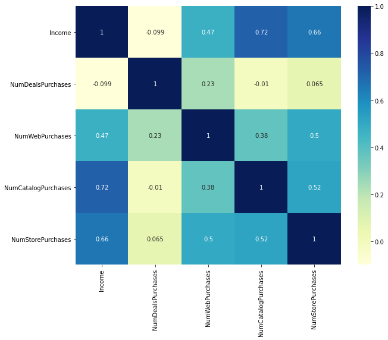

```python
corr=df[['Income', 'NumDealsPurchases', 'NumWebPurchases', 'NumCatalogPurchases', 'NumStorePurchases' ]].corr()

#Write your code here
#print(round(corr, 3))
plt.figure(figsize=(10,8))
sns.heatmap(corr, annot = True, cmap="YlGnBu")
corr
```

**Observations:**

- The strongest correlation is between income and catalog purchases at 0.72. Positive correlation meaning, higher the income, more catalog purchases.
  - This was noted earlier during analysis of percentage purchases from different channels for different income categories
- The next strongest correlation is between income and store purchases at 0.66.
- The overall correlation of income and purchases is positive for web, catalog, and store but slightly negative for deals (essentially no correlation).
- The correlation between each catalog, store, and web are all positive. This showed, overall as number of purchases increase, all platforms increase.
  - This was also noted earlier during analysis of percentage purchases from different channels for different income categories
- There is low to no correlation between the following:
  - Income and deals
  - Catalog purchases and deals
  - Store purchases and deals
- It appears most deals are purchased on the web.

As we know from our analysis we have done so far that customers with income, number of children, and amount spending on wines are the important factors. Let's try to come up with new customer profile on the basis of these 3 attributes and check what would be the acceptance rate for that customer profile.

```python
df3=df[df.Income>52000]
df4=df3[df3.MntWines>df3.MntWines.mean()]
new_profile=df4[df4.NumberofChildren==0]
```

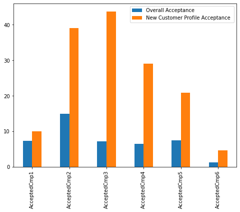

```python
#Calculating success rate of each campaign for both segments
success_campaign3=pd.DataFrame(success_campaign, columns=['Overall Acceptance'])

success_campaign4=pd.DataFrame((new_profile[Camp_cols].sum()/new_profile.shape[0])*100, columns=['New Customer Profile Acceptance '])

# plot
pd.concat([success_campaign3, success_campaign4], axis=1).plot(kind='bar', figsize=(8,6))
plt.title("")
plt.ylabel("")
plt.show()
```

**Observations:**

- Orange bars in the plot indicates that acceptance rate would have been high for new customer profile i.e. income greater than the mean income, no kid at home, amount spent of wines is greater than the mean amount spent on wines.

|  | Income | MntWines | MntFruits | MntMeatProducts | MntFishProducts | MntSweetProducts | MntGoldProds |
| --- | --- | --- | --- | --- | --- | --- | --- |
| Income | 1.000000 | 0.709355 | 0.522303 | 0.706407 | 0.536389 | 0.535831 | 0.399586 |
| MntWines | 0.709355 | 1.000000 | 0.387921 | 0.561441 | 0.398390 | 0.385290 | 0.385534 |
| MntFruits | 0.522303 | 0.387921 | 1.000000 | 0.541662 | 0.594110 | 0.566714 | 0.389459 |
| MntMeatProducts | 0.706407 | 0.561441 | 0.541662 | 1.000000 | 0.567451 | 0.522945 | 0.348077 |
| MntFishProducts | 0.536389 | 0.398390 | 0.594110 | 0.567451 | 1.000000 | 0.579173 | 0.421486 |
| MntSweetProducts | 0.535831 | 0.385290 | 0.566714 | 0.522945 | 0.579173 | 1.000000 | 0.368525 |
| MntGoldProds | 0.399586 | 0.385534 | 0.389459 | 0.348077 | 0.421486 | 0.368525 | 1.000000 |

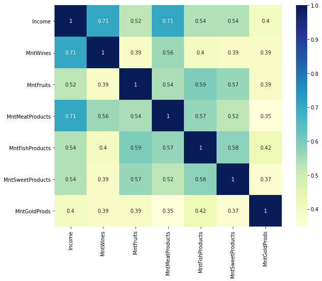

```python
corr2=df[['Income', 'MntWines', 'MntFruits', 'MntMeatProducts', 'MntFishProducts', 'MntSweetProducts', 'MntGoldProds' ]].corr()

#Write your code here
#print(round(corr, 3))
plt.figure(figsize=(10,8))
sns.heatmap(corr2, annot = True, cmap="YlGnBu")
corr2
```

### **Question 10: Based on your analysis, write the conclusions and recommendations for the CMO to help make the next marketing campaign strategy.**

## Conclusion and Recommendations

# Write your conclusions here

- The most successful campaign was the second as far as percent acceptance. However, after further investigation it might not have been the most profitable or have the most potential to make money.
- The sixth campaign looks to be the least successful based on percent acceptance. But, it was shown that individuals who accept the sixth campaign also spend a large amount of money on wine and gold.
  - The analysis showed the highest average amount of money was spent on wine.
  - Depending on the profit margins of wine the sixth campaign could actually be successful.
- Income analysis
  - Higher the income, higher the number of campaigns accepted.
  - For the first campaign, the acceptance percent is relatively similar for both income groups.
  - The second campaign is still the most successful for both income groups.
  - Campaign acceptance is low for lower income for 3 through 6.
- Customers who accept campaign six are loyal, return customers.
- For the customers accepting campaign 3, 4, 5, and 6 the average amount spent on wine is quite high. This also lined up within income analysis and wine analysis. Individuals with higher income spend more wine and meat.
- There are peaks in acceptance of campaigns for meat, fruit, sweets and fish around campaign 3 and 4.
- For the customers accepting campaign 3, 4, and 6 the average deals purchase is quite low. This lines up with the analysis that higher income group purchases deals less than lower income.
- The campaign acceptance changes based on the platform for the purchases. It was shown that higher income seem to prefer catalog purchases as well.
- Campaign two was successful with people who recently made purchases, possibly implying these were the more steady/consistant customers.
- There is a difference in campaign acceptance and education level.
  - Customers with basic education have only accepted campaign 1 and 2.
  - There is a higher accpetance of all campaigns the higher the education level
- The campaigns were more successful for customers without or less children.
  - Percent acceptance was low for all campaigns for people with 3 children.
- Widowed, single, and divorce all had high percent acceptance for campaign 2.
  - All three of these categories insinuate only one adult in the house.
- Percent accpetance for the countries looks similar to the overall percent accpetance of the campaigns.
- The mean amount spent by customers in the last 2 years is highest for wines followed by meat products.
- Customers with education level higher than basic spend the most on wine and meat. Customers with basic education spend the most on fish and gold.
- Purchase distribution for both marital status and country are both similar to the overall metrics.

# Write your recommendations here

- If looking to keep the same campaign profiles, the next target group should include the following individuals
  - High income
  - No children at home.
  - High level of education
- If looking to widen the success of the current group of customers, the campaigns should look to be more enticing to the following individuals
  - Lower income
  - People with children, especially more children
  - Lower education
- If repeating campaigns, target these groups for the current campaigns:
  - Target all income ranges for campaign 1 and 2.
  - Target high income for campaign 3 through 6, avoid low income.
- On the surface, acceptance of campaign 6 is low. However, the profit of campaign should be investigated. The campaign was successful with wine purchases, which was also the highest average amount spent. But average amount spent does not necessarily correlate to highest profit. Campaign 6 was also accepted by loyal customers. Depending on cost of the campaign, I would continue to use as you don't want to anger loyal customers.
- Catalog purchases are highest with high income individuals. If catalogs are sent to all customers, recommend stop sending catalogs to lower income customers.
- Most successful products are wine and meat and has the same purchase distribution in all countries. Depending on profit margins of other products, might look to drop some of them and focus more on wine and meat.
- Campaign acceptances looked similar across all counties. Continue to promote campaigns in all campaigns as long as campaign cost is the same for each country.